# Risk Factor Analysis

## Outcome Variable

**Outcome Variable:** y_rate_len

## Predictor Variables

**Intervention Variable:** vagbrth

**Adjustment Set:**

- arm
- sex
- W_mage
- meducyrs
- feducyrs
- hhwealth_quart
- W_mhtcm
- W_nrooms
- brthmon
- W_parity
- delta_W_mage
- delta_meducyrs
- delta_feducyrs
- delta_hhwealth_quart
- delta_W_mhtcm
- delta_W_nrooms
- delta_brthmon
- delta_W_parity

## Stratifying Variables

The analysis was stratified on these variable(s):

- agecat
- studyid
- country

## Data Summary

| agecat | studyid | country | vagbrth | n_cell | n |
| --- | --- | --- | --- | --- | --- |
| 0-3 months | ki1017093b-PROVIDE | BANGLADESH | 0 | 148 | 634 |
| 0-3 months | ki1017093b-PROVIDE | BANGLADESH | 1 | 486 | 634 |
| 0-3 months | ki1017093c-NIH-Crypto | BANGLADESH | 0 | 193 | 469 |
| 0-3 months | ki1017093c-NIH-Crypto | BANGLADESH | 1 | 276 | 469 |
| 0-3 months | kiGH5241-JiVitA-3 | BANGLADESH | 0 | 852 | 20010 |
| 0-3 months | kiGH5241-JiVitA-3 | BANGLADESH | 1 | 19158 | 20010 |
| 0-3 months | kiGH5241-JiVitA-4 | BANGLADESH | 0 | 100 | 1805 |
| 0-3 months | kiGH5241-JiVitA-4 | BANGLADESH | 1 | 1705 | 1805 |
| 0-3 months | ki1119695-PROBIT | BELARUS | 0 | 1424 | 12745 |
| 0-3 months | ki1119695-PROBIT | BELARUS | 1 | 11321 | 12745 |
| 0-3 months | ki1000108-CMC-V-BCS-2002 | INDIA | 0 | 10 | 87 |
| 0-3 months | ki1000108-CMC-V-BCS-2002 | INDIA | 1 | 77 | 87 |
| 0-3 months | ki1000108-IRC | INDIA | 0 | 66 | 377 |
| 0-3 months | ki1000108-IRC | INDIA | 1 | 311 | 377 |
| 0-3 months | ki1126311-ZVITAMBO | ZIMBABWE | 0 | 683 | 7802 |
| 0-3 months | ki1126311-ZVITAMBO | ZIMBABWE | 1 | 7119 | 7802 |
| 3-6 months | ki1017093b-PROVIDE | BANGLADESH | 0 | 133 | 574 |
| 3-6 months | ki1017093b-PROVIDE | BANGLADESH | 1 | 441 | 574 |
| 3-6 months | ki1017093c-NIH-Crypto | BANGLADESH | 0 | 182 | 443 |
| 3-6 months | ki1017093c-NIH-Crypto | BANGLADESH | 1 | 261 | 443 |
| 3-6 months | kiGH5241-JiVitA-3 | BANGLADESH | 0 | 769 | 12550 |
| 3-6 months | kiGH5241-JiVitA-3 | BANGLADESH | 1 | 11781 | 12550 |
| 3-6 months | kiGH5241-JiVitA-4 | BANGLADESH | 0 | 128 | 1762 |
| 3-6 months | kiGH5241-JiVitA-4 | BANGLADESH | 1 | 1634 | 1762 |
| 3-6 months | ki1119695-PROBIT | BELARUS | 0 | 1473 | 13309 |
| 3-6 months | ki1119695-PROBIT | BELARUS | 1 | 11836 | 13309 |
| 3-6 months | ki1000108-CMC-V-BCS-2002 | INDIA | 0 | 21 | 307 |
| 3-6 months | ki1000108-CMC-V-BCS-2002 | INDIA | 1 | 286 | 307 |
| 3-6 months | ki1000108-IRC | INDIA | 0 | 67 | 397 |
| 3-6 months | ki1000108-IRC | INDIA | 1 | 330 | 397 |
| 3-6 months | ki1066203-TanzaniaChild2 | TANZANIA, UNITED REPUBLIC OF | 0 | 159 | 1641 |
| 3-6 months | ki1066203-TanzaniaChild2 | TANZANIA, UNITED REPUBLIC OF | 1 | 1482 | 1641 |
| 3-6 months | ki1126311-ZVITAMBO | ZIMBABWE | 0 | 509 | 5842 |
| 3-6 months | ki1126311-ZVITAMBO | ZIMBABWE | 1 | 5333 | 5842 |
| 6-12 months | ki1017093b-PROVIDE | BANGLADESH | 0 | 121 | 545 |
| 6-12 months | ki1017093b-PROVIDE | BANGLADESH | 1 | 424 | 545 |
| 6-12 months | ki1017093c-NIH-Crypto | BANGLADESH | 0 | 176 | 420 |
| 6-12 months | ki1017093c-NIH-Crypto | BANGLADESH | 1 | 244 | 420 |
| 6-12 months | kiGH5241-JiVitA-3 | BANGLADESH | 0 | 591 | 9804 |
| 6-12 months | kiGH5241-JiVitA-3 | BANGLADESH | 1 | 9213 | 9804 |
| 6-12 months | kiGH5241-JiVitA-4 | BANGLADESH | 0 | 237 | 2808 |
| 6-12 months | kiGH5241-JiVitA-4 | BANGLADESH | 1 | 2571 | 2808 |
| 6-12 months | ki1119695-PROBIT | BELARUS | 0 | 1444 | 12896 |
| 6-12 months | ki1119695-PROBIT | BELARUS | 1 | 11452 | 12896 |
| 6-12 months | ki1000108-CMC-V-BCS-2002 | INDIA | 0 | 22 | 323 |
| 6-12 months | ki1000108-CMC-V-BCS-2002 | INDIA | 1 | 301 | 323 |
| 6-12 months | ki1000108-IRC | INDIA | 0 | 68 | 400 |
| 6-12 months | ki1000108-IRC | INDIA | 1 | 332 | 400 |
| 6-12 months | ki1066203-TanzaniaChild2 | TANZANIA, UNITED REPUBLIC OF | 0 | 102 | 1065 |
| 6-12 months | ki1066203-TanzaniaChild2 | TANZANIA, UNITED REPUBLIC OF | 1 | 963 | 1065 |
| 6-12 months | ki1126311-ZVITAMBO | ZIMBABWE | 0 | 369 | 4533 |
| 6-12 months | ki1126311-ZVITAMBO | ZIMBABWE | 1 | 4164 | 4533 |
| 12-24 months | ki1017093b-PROVIDE | BANGLADESH | 0 | 101 | 458 |
| 12-24 months | ki1017093b-PROVIDE | BANGLADESH | 1 | 357 | 458 |
| 12-24 months | ki1017093c-NIH-Crypto | BANGLADESH | 0 | 94 | 241 |
| 12-24 months | ki1017093c-NIH-Crypto | BANGLADESH | 1 | 147 | 241 |
| 12-24 months | kiGH5241-JiVitA-3 | BANGLADESH | 0 | 262 | 4628 |
| 12-24 months | kiGH5241-JiVitA-3 | BANGLADESH | 1 | 4366 | 4628 |
| 12-24 months | kiGH5241-JiVitA-4 | BANGLADESH | 0 | 257 | 3115 |
| 12-24 months | kiGH5241-JiVitA-4 | BANGLADESH | 1 | 2858 | 3115 |
| 12-24 months | ki1119695-PROBIT | BELARUS | 0 | 298 | 2533 |
| 12-24 months | ki1119695-PROBIT | BELARUS | 1 | 2235 | 2533 |
| 12-24 months | ki1000108-CMC-V-BCS-2002 | INDIA | 0 | 23 | 324 |
| 12-24 months | ki1000108-CMC-V-BCS-2002 | INDIA | 1 | 301 | 324 |
| 12-24 months | ki1000108-IRC | INDIA | 0 | 67 | 396 |
| 12-24 months | ki1000108-IRC | INDIA | 1 | 329 | 396 |
| 12-24 months | ki1066203-TanzaniaChild2 | TANZANIA, UNITED REPUBLIC OF | 0 | 1 | 2 |
| 12-24 months | ki1066203-TanzaniaChild2 | TANZANIA, UNITED REPUBLIC OF | 1 | 1 | 2 |
| 12-24 months | ki1126311-ZVITAMBO | ZIMBABWE | 0 | 20 | 297 |
| 12-24 months | ki1126311-ZVITAMBO | ZIMBABWE | 1 | 277 | 297 |

The following strata were considered:

- agecat: 0-3 months, studyid: ki1000108-CMC-V-BCS-2002, country: INDIA
- agecat: 0-3 months, studyid: ki1000108-IRC, country: INDIA
- agecat: 0-3 months, studyid: ki1017093b-PROVIDE, country: BANGLADESH
- agecat: 0-3 months, studyid: ki1017093c-NIH-Crypto, country: BANGLADESH
- agecat: 0-3 months, studyid: ki1119695-PROBIT, country: BELARUS
- agecat: 0-3 months, studyid: ki1126311-ZVITAMBO, country: ZIMBABWE
- agecat: 0-3 months, studyid: kiGH5241-JiVitA-3, country: BANGLADESH
- agecat: 0-3 months, studyid: kiGH5241-JiVitA-4, country: BANGLADESH
- agecat: 12-24 months, studyid: ki1000108-CMC-V-BCS-2002, country: INDIA
- agecat: 12-24 months, studyid: ki1000108-IRC, country: INDIA
- agecat: 12-24 months, studyid: ki1017093b-PROVIDE, country: BANGLADESH
- agecat: 12-24 months, studyid: ki1017093c-NIH-Crypto, country: BANGLADESH
- agecat: 12-24 months, studyid: ki1066203-TanzaniaChild2, country: TANZANIA, UNITED REPUBLIC OF
- agecat: 12-24 months, studyid: ki1119695-PROBIT, country: BELARUS
- agecat: 12-24 months, studyid: ki1126311-ZVITAMBO, country: ZIMBABWE
- agecat: 12-24 months, studyid: kiGH5241-JiVitA-3, country: BANGLADESH
- agecat: 12-24 months, studyid: kiGH5241-JiVitA-4, country: BANGLADESH
- agecat: 3-6 months, studyid: ki1000108-CMC-V-BCS-2002, country: INDIA
- agecat: 3-6 months, studyid: ki1000108-IRC, country: INDIA
- agecat: 3-6 months, studyid: ki1017093b-PROVIDE, country: BANGLADESH
- agecat: 3-6 months, studyid: ki1017093c-NIH-Crypto, country: BANGLADESH
- agecat: 3-6 months, studyid: ki1066203-TanzaniaChild2, country: TANZANIA, UNITED REPUBLIC OF
- agecat: 3-6 months, studyid: ki1119695-PROBIT, country: BELARUS
- agecat: 3-6 months, studyid: ki1126311-ZVITAMBO, country: ZIMBABWE
- agecat: 3-6 months, studyid: kiGH5241-JiVitA-3, country: BANGLADESH
- agecat: 3-6 months, studyid: kiGH5241-JiVitA-4, country: BANGLADESH
- agecat: 6-12 months, studyid: ki1000108-CMC-V-BCS-2002, country: INDIA
- agecat: 6-12 months, studyid: ki1000108-IRC, country: INDIA
- agecat: 6-12 months, studyid: ki1017093b-PROVIDE, country: BANGLADESH
- agecat: 6-12 months, studyid: ki1017093c-NIH-Crypto, country: BANGLADESH
- agecat: 6-12 months, studyid: ki1066203-TanzaniaChild2, country: TANZANIA, UNITED REPUBLIC OF
- agecat: 6-12 months, studyid: ki1119695-PROBIT, country: BELARUS
- agecat: 6-12 months, studyid: ki1126311-ZVITAMBO, country: ZIMBABWE
- agecat: 6-12 months, studyid: kiGH5241-JiVitA-3, country: BANGLADESH
- agecat: 6-12 months, studyid: kiGH5241-JiVitA-4, country: BANGLADESH

### Dropped Strata

Some strata were dropped due to rare outcomes:

- agecat: 12-24 months, studyid: ki1066203-TanzaniaChild2, country: TANZANIA, UNITED REPUBLIC OF

## Methods Detail

We’re interested in the causal parameters $E[Y_a]$ for all values of $a \in \mathcal{A}$. These parameters represent the mean outcome if, possibly contrary to fact, we intervened to set all units to have $A=a$. Under the randomization and positivity assumptions, these are identified by the statistical parameters $\psi_a=E_W[E_{Y|A,W}(Y|A=a,W)]$. In addition, we’re interested in the mean of $Y$, $E[Y]$ under no intervention (the observed mean). We will estimate these parameters by using SuperLearner to fit the relevant likelihood factors – $E_{Y|A,W}(Y|A=a,W)$ and $p(A=a|W)$, and then updating our likelihood fit using a joint TMLE.

For unadjusted analyses ($W=\{\}$), initial likelihoods were estimated using Lrnr_glm to estimate the simple $E(Y|A)$ and Lrnr_mean to estimate $p(A)$. For adjusted analyses, a small library containing Lrnr_glmnet, Lrnr_xgboost, and Lrnr_mean was used.

Having estimated these parameters, we will then use the delta method to estimate relative risks and attributable risks relative to a prespecified baseline level of $A$.

# Results Detail

## Results Plots

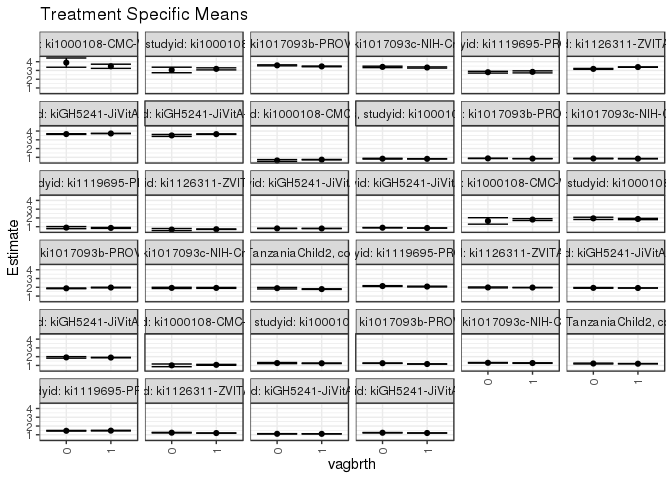

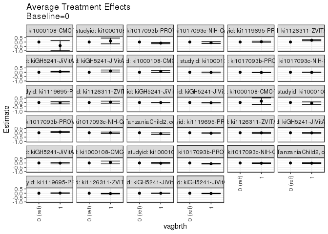

## Results Table

### Parameter: TSM

| agecat | studyid | country | intervention_level | baseline_level | estimate | ci_lower | ci_upper |
| --- | --- | --- | --- | --- | --- | --- | --- |
| 0-3 months | ki1000108-CMC-V-BCS-2002 | INDIA | 0 | NA | 3.8938384 | 3.3665210 | 4.4211557 |
| 0-3 months | ki1000108-CMC-V-BCS-2002 | INDIA | 1 | NA | 3.4754400 | 3.2381366 | 3.7127435 |
| 0-3 months | ki1000108-IRC | INDIA | 0 | NA | 3.0555252 | 2.7408198 | 3.3702307 |
| 0-3 months | ki1000108-IRC | INDIA | 1 | NA | 3.1801078 | 3.0629164 | 3.2972993 |
| 0-3 months | ki1017093b-PROVIDE | BANGLADESH | 0 | NA | 3.5837422 | 3.5278729 | 3.6396114 |
| 0-3 months | ki1017093b-PROVIDE | BANGLADESH | 1 | NA | 3.4610779 | 3.4201358 | 3.5020201 |
| 0-3 months | ki1017093c-NIH-Crypto | BANGLADESH | 0 | NA | 3.4057490 | 3.3251581 | 3.4863400 |
| 0-3 months | ki1017093c-NIH-Crypto | BANGLADESH | 1 | NA | 3.3364427 | 3.2681046 | 3.4047807 |
| 0-3 months | ki1119695-PROBIT | BELARUS | 0 | NA | 2.7983244 | 2.6979557 | 2.8986932 |
| 0-3 months | ki1119695-PROBIT | BELARUS | 1 | NA | 2.8364653 | 2.7206575 | 2.9522732 |
| 0-3 months | ki1126311-ZVITAMBO | ZIMBABWE | 0 | NA | 3.1780015 | 3.1234753 | 3.2325277 |
| 0-3 months | ki1126311-ZVITAMBO | ZIMBABWE | 1 | NA | 3.3852230 | 3.3633385 | 3.4071074 |
| 0-3 months | kiGH5241-JiVitA-3 | BANGLADESH | 0 | NA | 3.6547316 | 3.6134523 | 3.6960108 |
| 0-3 months | kiGH5241-JiVitA-3 | BANGLADESH | 1 | NA | 3.7218778 | 3.7112803 | 3.7324752 |
| 0-3 months | kiGH5241-JiVitA-4 | BANGLADESH | 0 | NA | 3.4997023 | 3.3891169 | 3.6102878 |
| 0-3 months | kiGH5241-JiVitA-4 | BANGLADESH | 1 | NA | 3.6482535 | 3.6163615 | 3.6801455 |
| 3-6 months | ki1000108-CMC-V-BCS-2002 | INDIA | 0 | NA | 1.6578641 | 1.2908296 | 2.0248986 |
| 3-6 months | ki1000108-CMC-V-BCS-2002 | INDIA | 1 | NA | 1.8145027 | 1.7098177 | 1.9191877 |
| 3-6 months | ki1000108-IRC | INDIA | 0 | NA | 1.9533886 | 1.8260373 | 2.0807399 |
| 3-6 months | ki1000108-IRC | INDIA | 1 | NA | 1.8800762 | 1.8113463 | 1.9488061 |
| 3-6 months | ki1017093b-PROVIDE | BANGLADESH | 0 | NA | 1.8836418 | 1.8415269 | 1.9257567 |
| 3-6 months | ki1017093b-PROVIDE | BANGLADESH | 1 | NA | 1.9715657 | 1.9352354 | 2.0078960 |
| 3-6 months | ki1017093c-NIH-Crypto | BANGLADESH | 0 | NA | 1.9318961 | 1.8657728 | 1.9980194 |
| 3-6 months | ki1017093c-NIH-Crypto | BANGLADESH | 1 | NA | 1.9289222 | 1.8770118 | 1.9808326 |
| 3-6 months | ki1066203-TanzaniaChild2 | TANZANIA, UNITED REPUBLIC OF | 0 | NA | 1.8975996 | 1.8121605 | 1.9830387 |
| 3-6 months | ki1066203-TanzaniaChild2 | TANZANIA, UNITED REPUBLIC OF | 1 | NA | 1.7934360 | 1.7561342 | 1.8307377 |
| 3-6 months | ki1119695-PROBIT | BELARUS | 0 | NA | 2.1401878 | 2.0935049 | 2.1868706 |
| 3-6 months | ki1119695-PROBIT | BELARUS | 1 | NA | 2.0851453 | 2.0408436 | 2.1294469 |
| 3-6 months | ki1126311-ZVITAMBO | ZIMBABWE | 0 | NA | 1.9815850 | 1.9293660 | 2.0338039 |
| 3-6 months | ki1126311-ZVITAMBO | ZIMBABWE | 1 | NA | 1.9716063 | 1.9506516 | 1.9925610 |
| 3-6 months | kiGH5241-JiVitA-3 | BANGLADESH | 0 | NA | 1.9333583 | 1.8938796 | 1.9728370 |
| 3-6 months | kiGH5241-JiVitA-3 | BANGLADESH | 1 | NA | 1.9189374 | 1.9081155 | 1.9297592 |
| 3-6 months | kiGH5241-JiVitA-4 | BANGLADESH | 0 | NA | 1.9126481 | 1.8259433 | 1.9993529 |
| 3-6 months | kiGH5241-JiVitA-4 | BANGLADESH | 1 | NA | 1.8963814 | 1.8652482 | 1.9275147 |
| 6-12 months | ki1000108-CMC-V-BCS-2002 | INDIA | 0 | NA | 1.0081895 | 0.8541081 | 1.1622709 |
| 6-12 months | ki1000108-CMC-V-BCS-2002 | INDIA | 1 | NA | 1.0665390 | 1.0167479 | 1.1163301 |
| 6-12 months | ki1000108-IRC | INDIA | 0 | NA | 1.2682347 | 1.2075017 | 1.3289677 |
| 6-12 months | ki1000108-IRC | INDIA | 1 | NA | 1.2437047 | 1.2119284 | 1.2754811 |
| 6-12 months | ki1017093b-PROVIDE | BANGLADESH | 0 | NA | 1.2522327 | 1.2288776 | 1.2755879 |
| 6-12 months | ki1017093b-PROVIDE | BANGLADESH | 1 | NA | 1.1604673 | 1.1420422 | 1.1788924 |
| 6-12 months | ki1017093c-NIH-Crypto | BANGLADESH | 0 | NA | 1.2965123 | 1.2637523 | 1.3292722 |
| 6-12 months | ki1017093c-NIH-Crypto | BANGLADESH | 1 | NA | 1.2699824 | 1.2389767 | 1.3009882 |
| 6-12 months | ki1066203-TanzaniaChild2 | TANZANIA, UNITED REPUBLIC OF | 0 | NA | 1.2166289 | 1.1693733 | 1.2638845 |
| 6-12 months | ki1066203-TanzaniaChild2 | TANZANIA, UNITED REPUBLIC OF | 1 | NA | 1.1945387 | 1.1720308 | 1.2170466 |
| 6-12 months | ki1119695-PROBIT | BELARUS | 0 | NA | 1.4540095 | 1.4170608 | 1.4909581 |
| 6-12 months | ki1119695-PROBIT | BELARUS | 1 | NA | 1.4718338 | 1.4328074 | 1.5108602 |
| 6-12 months | ki1126311-ZVITAMBO | ZIMBABWE | 0 | NA | 1.2382654 | 1.2048902 | 1.2716406 |
| 6-12 months | ki1126311-ZVITAMBO | ZIMBABWE | 1 | NA | 1.1967858 | 1.1854846 | 1.2080870 |
| 6-12 months | kiGH5241-JiVitA-3 | BANGLADESH | 0 | NA | 1.1112827 | 1.0896181 | 1.1329473 |
| 6-12 months | kiGH5241-JiVitA-3 | BANGLADESH | 1 | NA | 1.1060431 | 1.0991702 | 1.1129160 |
| 6-12 months | kiGH5241-JiVitA-4 | BANGLADESH | 0 | NA | 1.2326028 | 1.2055529 | 1.2596526 |
| 6-12 months | kiGH5241-JiVitA-4 | BANGLADESH | 1 | NA | 1.2027656 | 1.1915167 | 1.2140146 |
| 12-24 months | ki1000108-CMC-V-BCS-2002 | INDIA | 0 | NA | 0.6445233 | 0.5446708 | 0.7443759 |
| 12-24 months | ki1000108-CMC-V-BCS-2002 | INDIA | 1 | NA | 0.7350451 | 0.7078925 | 0.7621976 |
| 12-24 months | ki1000108-IRC | INDIA | 0 | NA | 0.8429795 | 0.7991456 | 0.8868134 |
| 12-24 months | ki1000108-IRC | INDIA | 1 | NA | 0.8267380 | 0.8051035 | 0.8483726 |
| 12-24 months | ki1017093b-PROVIDE | BANGLADESH | 0 | NA | 0.8801696 | 0.8629403 | 0.8973988 |
| 12-24 months | ki1017093b-PROVIDE | BANGLADESH | 1 | NA | 0.8562360 | 0.8433292 | 0.8691429 |
| 12-24 months | ki1017093c-NIH-Crypto | BANGLADESH | 0 | NA | 0.8634105 | 0.8328731 | 0.8939479 |
| 12-24 months | ki1017093c-NIH-Crypto | BANGLADESH | 1 | NA | 0.8496372 | 0.8285284 | 0.8707460 |
| 12-24 months | ki1119695-PROBIT | BELARUS | 0 | NA | 0.8932808 | 0.7742681 | 1.0122936 |
| 12-24 months | ki1119695-PROBIT | BELARUS | 1 | NA | 0.8588043 | 0.8038272 | 0.9137814 |
| 12-24 months | ki1126311-ZVITAMBO | ZIMBABWE | 0 | NA | 0.6744181 | 0.5562805 | 0.7925556 |
| 12-24 months | ki1126311-ZVITAMBO | ZIMBABWE | 1 | NA | 0.7122383 | 0.6855860 | 0.7388907 |
| 12-24 months | kiGH5241-JiVitA-3 | BANGLADESH | 0 | NA | 0.8038479 | 0.7911224 | 0.8165734 |
| 12-24 months | kiGH5241-JiVitA-3 | BANGLADESH | 1 | NA | 0.7950916 | 0.7897375 | 0.8004457 |
| 12-24 months | kiGH5241-JiVitA-4 | BANGLADESH | 0 | NA | 0.8832342 | 0.8625876 | 0.9038809 |
| 12-24 months | kiGH5241-JiVitA-4 | BANGLADESH | 1 | NA | 0.8491622 | 0.8430913 | 0.8552331 |

### Parameter: E(Y)

| agecat | studyid | country | intervention_level | baseline_level | estimate | ci_lower | ci_upper |
| --- | --- | --- | --- | --- | --- | --- | --- |
| 0-3 months | ki1000108-CMC-V-BCS-2002 | INDIA | NA | NA | 3.5235318 | 3.3031217 | 3.7439420 |
| 0-3 months | ki1000108-IRC | INDIA | NA | NA | 3.1729204 | 3.0609523 | 3.2848884 |
| 0-3 months | ki1017093b-PROVIDE | BANGLADESH | NA | NA | 3.4826706 | 3.4434873 | 3.5218539 |
| 0-3 months | ki1017093c-NIH-Crypto | BANGLADESH | NA | NA | 3.3649642 | 3.3127253 | 3.4172032 |
| 0-3 months | ki1119695-PROBIT | BELARUS | NA | NA | 2.8355739 | 2.7218468 | 2.9493011 |
| 0-3 months | ki1126311-ZVITAMBO | ZIMBABWE | NA | NA | 3.3690248 | 3.3480527 | 3.3899969 |
| 0-3 months | kiGH5241-JiVitA-3 | BANGLADESH | NA | NA | 3.7184807 | 3.7081255 | 3.7288360 |
| 0-3 months | kiGH5241-JiVitA-4 | BANGLADESH | NA | NA | 3.6382952 | 3.6070008 | 3.6695897 |
| 3-6 months | ki1000108-CMC-V-BCS-2002 | INDIA | NA | NA | 1.8037880 | 1.7029866 | 1.9045894 |
| 3-6 months | ki1000108-IRC | INDIA | NA | NA | 1.8806738 | 1.8168757 | 1.9444719 |
| 3-6 months | ki1017093b-PROVIDE | BANGLADESH | NA | NA | 1.9654454 | 1.9303798 | 2.0005110 |
| 3-6 months | ki1017093c-NIH-Crypto | BANGLADESH | NA | NA | 1.9301440 | 1.8892000 | 1.9710881 |
| 3-6 months | ki1066203-TanzaniaChild2 | TANZANIA, UNITED REPUBLIC OF | NA | NA | 1.7952908 | 1.7590835 | 1.8314981 |
| 3-6 months | ki1119695-PROBIT | BELARUS | NA | NA | 2.0914863 | 2.0503474 | 2.1326251 |
| 3-6 months | ki1126311-ZVITAMBO | ZIMBABWE | NA | NA | 1.9728181 | 1.9527936 | 1.9928426 |
| 3-6 months | kiGH5241-JiVitA-3 | BANGLADESH | NA | NA | 1.9201286 | 1.9096400 | 1.9306171 |
| 3-6 months | kiGH5241-JiVitA-4 | BANGLADESH | NA | NA | 1.8984901 | 1.8679171 | 1.9290631 |
| 6-12 months | ki1000108-CMC-V-BCS-2002 | INDIA | NA | NA | 1.0624474 | 1.0146679 | 1.1102268 |
| 6-12 months | ki1000108-IRC | INDIA | NA | NA | 1.2485668 | 1.2193308 | 1.2778028 |
| 6-12 months | ki1017093b-PROVIDE | BANGLADESH | NA | NA | 1.1731762 | 1.1558671 | 1.1904853 |
| 6-12 months | ki1017093c-NIH-Crypto | BANGLADESH | NA | NA | 1.2446145 | 1.2215001 | 1.2677288 |
| 6-12 months | ki1066203-TanzaniaChild2 | TANZANIA, UNITED REPUBLIC OF | NA | NA | 1.1965957 | 1.1748037 | 1.2183876 |
| 6-12 months | ki1119695-PROBIT | BELARUS | NA | NA | 1.4709224 | 1.4326640 | 1.5091808 |
| 6-12 months | ki1126311-ZVITAMBO | ZIMBABWE | NA | NA | 1.1990544 | 1.1881340 | 1.2099748 |
| 6-12 months | kiGH5241-JiVitA-3 | BANGLADESH | NA | NA | 1.1069052 | 1.1001881 | 1.1136222 |
| 6-12 months | kiGH5241-JiVitA-4 | BANGLADESH | NA | NA | 1.2052595 | 1.1944986 | 1.2160203 |
| 12-24 months | ki1000108-CMC-V-BCS-2002 | INDIA | NA | NA | 0.7397013 | 0.7128622 | 0.7665404 |
| 12-24 months | ki1000108-IRC | INDIA | NA | NA | 0.8294859 | 0.8099817 | 0.8489901 |
| 12-24 months | ki1017093b-PROVIDE | BANGLADESH | NA | NA | 0.8575519 | 0.8455586 | 0.8695452 |
| 12-24 months | ki1017093c-NIH-Crypto | BANGLADESH | NA | NA | 0.8550127 | 0.8373147 | 0.8727107 |
| 12-24 months | ki1119695-PROBIT | BELARUS | NA | NA | 0.8601486 | 0.8069287 | 0.9133686 |
| 12-24 months | ki1126311-ZVITAMBO | ZIMBABWE | NA | NA | 0.7096907 | 0.6834338 | 0.7359476 |
| 12-24 months | kiGH5241-JiVitA-3 | BANGLADESH | NA | NA | 0.7966279 | 0.7913026 | 0.8019533 |
| 12-24 months | kiGH5241-JiVitA-4 | BANGLADESH | NA | NA | 0.8510893 | 0.8452149 | 0.8569636 |

### Parameter: ATE

| agecat | studyid | country | intervention_level | baseline_level | estimate | ci_lower | ci_upper |
| --- | --- | --- | --- | --- | --- | --- | --- |
| 0-3 months | ki1000108-CMC-V-BCS-2002 | INDIA | 0 | 0 | 0.0000000 | 0.0000000 | 0.0000000 |
| 0-3 months | ki1000108-CMC-V-BCS-2002 | INDIA | 1 | 0 | -0.4183983 | -0.9966513 | 0.1598547 |
| 0-3 months | ki1000108-IRC | INDIA | 0 | 0 | 0.0000000 | 0.0000000 | 0.0000000 |
| 0-3 months | ki1000108-IRC | INDIA | 1 | 0 | 0.1245826 | -0.2111395 | 0.4603047 |
| 0-3 months | ki1017093b-PROVIDE | BANGLADESH | 0 | 0 | 0.0000000 | 0.0000000 | 0.0000000 |
| 0-3 months | ki1017093b-PROVIDE | BANGLADESH | 1 | 0 | -0.1226642 | -0.1920009 | -0.0533276 |
| 0-3 months | ki1017093c-NIH-Crypto | BANGLADESH | 0 | 0 | 0.0000000 | 0.0000000 | 0.0000000 |
| 0-3 months | ki1017093c-NIH-Crypto | BANGLADESH | 1 | 0 | -0.0693064 | -0.1749419 | 0.0363292 |
| 0-3 months | ki1119695-PROBIT | BELARUS | 0 | 0 | 0.0000000 | 0.0000000 | 0.0000000 |
| 0-3 months | ki1119695-PROBIT | BELARUS | 1 | 0 | 0.0381409 | -0.0207591 | 0.0970409 |
| 0-3 months | ki1126311-ZVITAMBO | ZIMBABWE | 0 | 0 | 0.0000000 | 0.0000000 | 0.0000000 |
| 0-3 months | ki1126311-ZVITAMBO | ZIMBABWE | 1 | 0 | 0.2072215 | 0.1488230 | 0.2656199 |
| 0-3 months | kiGH5241-JiVitA-3 | BANGLADESH | 0 | 0 | 0.0000000 | 0.0000000 | 0.0000000 |
| 0-3 months | kiGH5241-JiVitA-3 | BANGLADESH | 1 | 0 | 0.0671462 | 0.0248983 | 0.1093941 |
| 0-3 months | kiGH5241-JiVitA-4 | BANGLADESH | 0 | 0 | 0.0000000 | 0.0000000 | 0.0000000 |
| 0-3 months | kiGH5241-JiVitA-4 | BANGLADESH | 1 | 0 | 0.1485512 | 0.0340373 | 0.2630652 |
| 3-6 months | ki1000108-CMC-V-BCS-2002 | INDIA | 0 | 0 | 0.0000000 | 0.0000000 | 0.0000000 |
| 3-6 months | ki1000108-CMC-V-BCS-2002 | INDIA | 1 | 0 | 0.1566386 | -0.2250331 | 0.5383103 |
| 3-6 months | ki1000108-IRC | INDIA | 0 | 0 | 0.0000000 | 0.0000000 | 0.0000000 |
| 3-6 months | ki1000108-IRC | INDIA | 1 | 0 | -0.0733124 | -0.2168879 | 0.0702631 |
| 3-6 months | ki1017093b-PROVIDE | BANGLADESH | 0 | 0 | 0.0000000 | 0.0000000 | 0.0000000 |
| 3-6 months | ki1017093b-PROVIDE | BANGLADESH | 1 | 0 | 0.0879239 | 0.0369311 | 0.1389167 |
| 3-6 months | ki1017093c-NIH-Crypto | BANGLADESH | 0 | 0 | 0.0000000 | 0.0000000 | 0.0000000 |
| 3-6 months | ki1017093c-NIH-Crypto | BANGLADESH | 1 | 0 | -0.0029739 | -0.0869639 | 0.0810161 |
| 3-6 months | ki1066203-TanzaniaChild2 | TANZANIA, UNITED REPUBLIC OF | 0 | 0 | 0.0000000 | 0.0000000 | 0.0000000 |
| 3-6 months | ki1066203-TanzaniaChild2 | TANZANIA, UNITED REPUBLIC OF | 1 | 0 | -0.1041637 | -0.1963814 | -0.0119459 |
| 3-6 months | ki1119695-PROBIT | BELARUS | 0 | 0 | 0.0000000 | 0.0000000 | 0.0000000 |
| 3-6 months | ki1119695-PROBIT | BELARUS | 1 | 0 | -0.0550425 | -0.1112323 | 0.0011473 |
| 3-6 months | ki1126311-ZVITAMBO | ZIMBABWE | 0 | 0 | 0.0000000 | 0.0000000 | 0.0000000 |
| 3-6 months | ki1126311-ZVITAMBO | ZIMBABWE | 1 | 0 | -0.0099786 | -0.0658952 | 0.0459379 |
| 3-6 months | kiGH5241-JiVitA-3 | BANGLADESH | 0 | 0 | 0.0000000 | 0.0000000 | 0.0000000 |
| 3-6 months | kiGH5241-JiVitA-3 | BANGLADESH | 1 | 0 | -0.0144209 | -0.0554557 | 0.0266139 |
| 3-6 months | kiGH5241-JiVitA-4 | BANGLADESH | 0 | 0 | 0.0000000 | 0.0000000 | 0.0000000 |
| 3-6 months | kiGH5241-JiVitA-4 | BANGLADESH | 1 | 0 | -0.0162667 | -0.1070616 | 0.0745283 |
| 6-12 months | ki1000108-CMC-V-BCS-2002 | INDIA | 0 | 0 | 0.0000000 | 0.0000000 | 0.0000000 |
| 6-12 months | ki1000108-CMC-V-BCS-2002 | INDIA | 1 | 0 | 0.0583495 | -0.1032085 | 0.2199075 |
| 6-12 months | ki1000108-IRC | INDIA | 0 | 0 | 0.0000000 | 0.0000000 | 0.0000000 |
| 6-12 months | ki1000108-IRC | INDIA | 1 | 0 | -0.0245300 | -0.0920173 | 0.0429573 |
| 6-12 months | ki1017093b-PROVIDE | BANGLADESH | 0 | 0 | 0.0000000 | 0.0000000 | 0.0000000 |
| 6-12 months | ki1017093b-PROVIDE | BANGLADESH | 1 | 0 | -0.0917654 | -0.1213408 | -0.0621899 |
| 6-12 months | ki1017093c-NIH-Crypto | BANGLADESH | 0 | 0 | 0.0000000 | 0.0000000 | 0.0000000 |
| 6-12 months | ki1017093c-NIH-Crypto | BANGLADESH | 1 | 0 | -0.0265298 | -0.0720051 | 0.0189454 |
| 6-12 months | ki1066203-TanzaniaChild2 | TANZANIA, UNITED REPUBLIC OF | 0 | 0 | 0.0000000 | 0.0000000 | 0.0000000 |
| 6-12 months | ki1066203-TanzaniaChild2 | TANZANIA, UNITED REPUBLIC OF | 1 | 0 | -0.0220902 | -0.0732226 | 0.0290423 |
| 6-12 months | ki1119695-PROBIT | BELARUS | 0 | 0 | 0.0000000 | 0.0000000 | 0.0000000 |
| 6-12 months | ki1119695-PROBIT | BELARUS | 1 | 0 | 0.0178243 | -0.0128364 | 0.0484850 |
| 6-12 months | ki1126311-ZVITAMBO | ZIMBABWE | 0 | 0 | 0.0000000 | 0.0000000 | 0.0000000 |
| 6-12 months | ki1126311-ZVITAMBO | ZIMBABWE | 1 | 0 | -0.0414796 | -0.0765061 | -0.0064532 |
| 6-12 months | kiGH5241-JiVitA-3 | BANGLADESH | 0 | 0 | 0.0000000 | 0.0000000 | 0.0000000 |
| 6-12 months | kiGH5241-JiVitA-3 | BANGLADESH | 1 | 0 | -0.0052396 | -0.0283305 | 0.0178513 |
| 6-12 months | kiGH5241-JiVitA-4 | BANGLADESH | 0 | 0 | 0.0000000 | 0.0000000 | 0.0000000 |
| 6-12 months | kiGH5241-JiVitA-4 | BANGLADESH | 1 | 0 | -0.0298371 | -0.0588579 | -0.0008164 |
| 12-24 months | ki1000108-CMC-V-BCS-2002 | INDIA | 0 | 0 | 0.0000000 | 0.0000000 | 0.0000000 |
| 12-24 months | ki1000108-CMC-V-BCS-2002 | INDIA | 1 | 0 | 0.0905217 | -0.0128521 | 0.1938955 |
| 12-24 months | ki1000108-IRC | INDIA | 0 | 0 | 0.0000000 | 0.0000000 | 0.0000000 |
| 12-24 months | ki1000108-IRC | INDIA | 1 | 0 | -0.0162414 | -0.0649733 | 0.0324904 |
| 12-24 months | ki1017093b-PROVIDE | BANGLADESH | 0 | 0 | 0.0000000 | 0.0000000 | 0.0000000 |
| 12-24 months | ki1017093b-PROVIDE | BANGLADESH | 1 | 0 | -0.0239335 | -0.0454764 | -0.0023906 |
| 12-24 months | ki1017093c-NIH-Crypto | BANGLADESH | 0 | 0 | 0.0000000 | 0.0000000 | 0.0000000 |
| 12-24 months | ki1017093c-NIH-Crypto | BANGLADESH | 1 | 0 | -0.0137733 | -0.0506184 | 0.0230718 |
| 12-24 months | ki1119695-PROBIT | BELARUS | 0 | 0 | 0.0000000 | 0.0000000 | 0.0000000 |
| 12-24 months | ki1119695-PROBIT | BELARUS | 1 | 0 | -0.0344766 | -0.1600070 | 0.0910539 |
| 12-24 months | ki1126311-ZVITAMBO | ZIMBABWE | 0 | 0 | 0.0000000 | 0.0000000 | 0.0000000 |
| 12-24 months | ki1126311-ZVITAMBO | ZIMBABWE | 1 | 0 | 0.0378203 | -0.0828176 | 0.1584581 |
| 12-24 months | kiGH5241-JiVitA-3 | BANGLADESH | 0 | 0 | 0.0000000 | 0.0000000 | 0.0000000 |
| 12-24 months | kiGH5241-JiVitA-3 | BANGLADESH | 1 | 0 | -0.0087563 | -0.0221578 | 0.0046452 |
| 12-24 months | kiGH5241-JiVitA-4 | BANGLADESH | 0 | 0 | 0.0000000 | 0.0000000 | 0.0000000 |
| 12-24 months | kiGH5241-JiVitA-4 | BANGLADESH | 1 | 0 | -0.0340720 | -0.0553928 | -0.0127512 |